# Analyzing The School Dataset

### Plotting `'Frequency Of Internet Usage'`

Let's check the histogram.

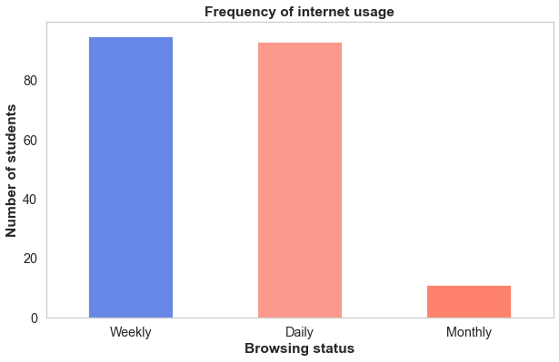

```python
plt.figure(figsize=(10, 6))
sns.set(font_scale=1.3)
sns.set_style("whitegrid", {'axes.grid' : False})


categorical_bar_plot(school_df['Frequency Of Internet Usage'], color=['royalblue', 'salmon', 'tomato'],
                     title='Frequency of internet usage', xlabel='Browsing status')

plt.show()
```

Let's check the distribution of this feature against the target i.e. `'Academic Performance'`.

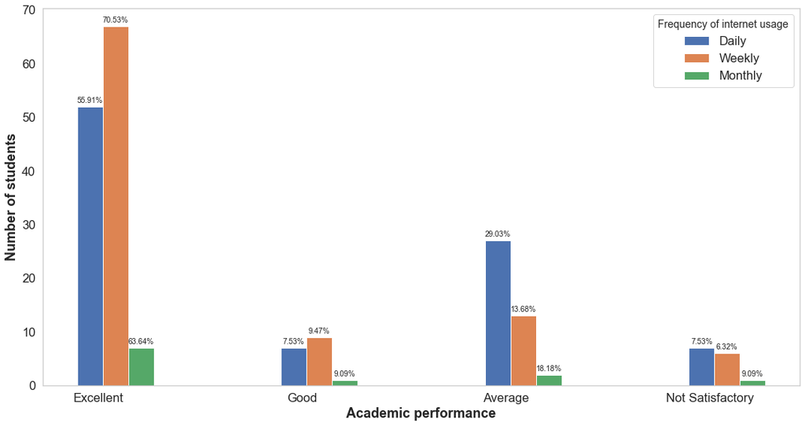

```python
sns.set(font_scale=1.5)
sns.set_style("whitegrid", {'axes.grid' : False})

dictionary = cat_vs_cat_bar_plot(school_df, 'Frequency Of Internet Usage',
                              ['Daily', 'Weekly', 'Monthly'])

labels = ['Excellent', 'Good', 'Average', 'Not Satisfactory']
x = np.arange(len(labels))
width = 0.25

fig, ax = plt.subplots(figsize=(15, 8))
fig.subplots_adjust(top=0.5, bottom=0.1, hspace=0.5, wspace=0.2)

rects1 = ax.bar(x - width/2, dictionary['Daily'], width/2, label = 'Daily')
rects2 = ax.bar(x, dictionary['Weekly'], width/2, label = 'Weekly')
rects3 = ax.bar(x + width/2, dictionary['Monthly'], width/2, label = 'Monthly')

ax.set_ylabel('Number of students', fontweight = 'bold')
ax.set_xlabel('Academic performance', fontweight = 'bold')
# ax.set_title('Frequency Of Internet Usage vs Academic Performance', fontweight = 'bold')
ax.set_xticks(x - width/3)
ax.set_xticklabels(labels)
ax.legend(title='Frequency of internet usage', title_fontsize=14)

sns.set(font_scale=0.85)

autolabel(rects1)
autolabel(rects2)
autolabel(rects3)

fig.tight_layout()

plt.show()
```

### Plotting `'Place Of Student's Residence'`

Let's check the histogram.

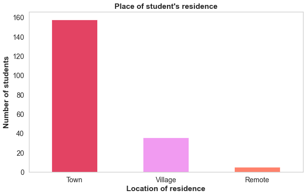

```python
plt.figure(figsize=(10, 6))
sns.set(font_scale=1.3)
sns.set_style("whitegrid", {'axes.grid' : False})

categorical_bar_plot(school_df['Place Of Student\'s Residence'], color=['crimson', 'violet', 'tomato'],
                     title='Place of student\'s residence', xlabel='Location of residence')

plt.show()
```

### Plotting `'Purpose Of Internet Use'`

Let's check the histogram.

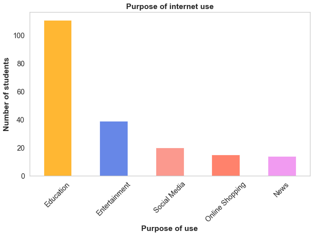

```python
plt.figure(figsize=(10, 6))
sns.set(font_scale=1.3)
sns.set_style("whitegrid", {'axes.grid' : False})

categorical_bar_plot(school_df['Purpose Of Internet Use'], rot=45,
                     color = ['orange', 'royalblue', 'salmon', 'tomato', 'violet', 'crimson'],
                     title='Purpose of internet use', xlabel='Purpose of use')

plt.show()
```

Let's check the distribution of this feature against the target i.e. `'Academic Performance'`.

```
Saving figure Purpose_Of_Internet_Use_WRT_Academic_Performance
```

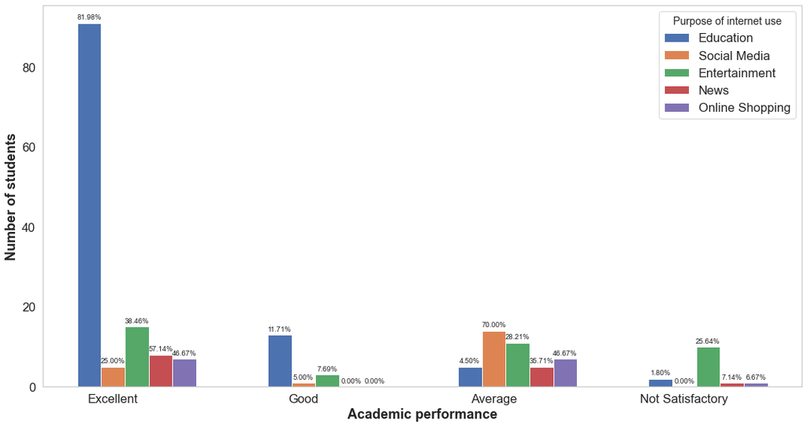

```python
sns.set(font_scale=1.5)
sns.set_style("whitegrid", {'axes.grid' : False})

dictionary = cat_vs_cat_bar_plot(school_df, 'Purpose Of Internet Use',
                              school_df['Purpose Of Internet Use'].value_counts().index.tolist())

labels = ['Excellent', 'Good', 'Average', 'Not Satisfactory']
x = np.arange(len(labels))
width = 0.25

fig, ax = plt.subplots(figsize=(15, 8))
fig.subplots_adjust(top=0.5, bottom=0.1, hspace=0.5, wspace=0.2)

rects1 = ax.bar(x - width, dictionary['Education'], width/2, label = 'Education')
rects2 = ax.bar(x - width/2, dictionary['Social Media'], width/2, label = 'Social Media')
rects3 = ax.bar(x, dictionary['Entertainment'], width/2, label = 'Entertainment')
rects4 = ax.bar(x + width/2, dictionary['News'], width/2, label = 'News')
rects5 = ax.bar(x + width, dictionary['Online Shopping'], width/2, label = 'Online Shopping')

ax.set_ylabel('Number of students', fontweight = 'bold')
ax.set_xlabel('Academic performance', fontweight = 'bold')
# ax.set_title('Purpose Of Internet Use W.R.T. Academic Performance', fontweight = 'bold')
ax.set_xticks(x - width/2)
ax.set_xticklabels(labels)
ax.legend(title='Purpose of internet use', title_fontsize=14, loc='upper right')

sns.set(font_scale=0.8)

autolabel(rects1)
autolabel(rects2)
autolabel(rects3)
autolabel(rects4)
autolabel(rects5)

fig.tight_layout()

save_fig('Purpose_Of_Internet_Use_WRT_Academic_Performance')

plt.show()
```

### Plotting `'Browsing Purpose'`

Let's check the histogram.

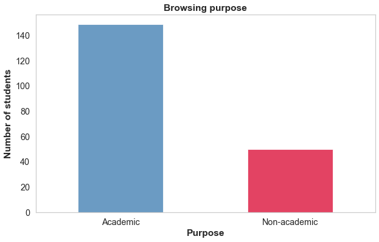

```python
plt.figure(figsize=(10, 6))
sns.set(font_scale=1.3)
sns.set_style("whitegrid", {'axes.grid' : False})

categorical_bar_plot(school_df['Browsing Purpose'], title='Browsing purpose',
                     xlabel='Purpose')

plt.show()
```

Let's check the distribution of this feature against the target i.e. `'Academic Performance'`.

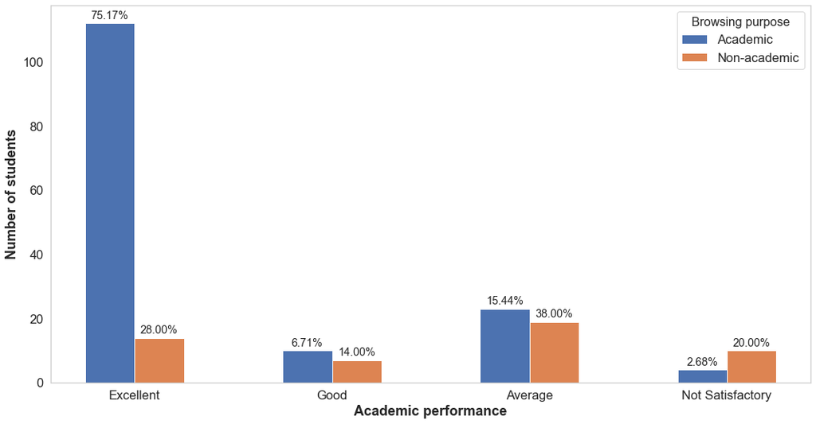

```python
sns.set(font_scale=1.5)
sns.set_style("whitegrid", {'axes.grid' : False})

dictionary = cat_vs_cat_bar_plot(school_df, 'Browsing Purpose',
                              school_df['Browsing Purpose'].value_counts().index.tolist())

labels = ['Excellent', 'Good', 'Average', 'Not Satisfactory']
x = np.arange(len(labels))
width = 0.25

fig, ax = plt.subplots(figsize=(15, 8))
fig.subplots_adjust(top=0.5, bottom=0.1, hspace=0.5, wspace=0.2)

rects1 = ax.bar(x - width, dictionary['Academic'], width, label = 'Academic')
rects2 = ax.bar(x, dictionary['Non-academic'], width, label = 'Non-academic')

ax.set_ylabel('Number of students', fontweight = 'bold')
ax.set_xlabel('Academic performance', fontweight = 'bold')
# ax.set_title('Browsing Purpose vs Academic Performance', fontweight = 'bold')
ax.set_xticks(x - width/2)
ax.set_xticklabels(labels)
ax.legend(title='Browsing purpose', title_fontsize=16, loc='upper right')

sns.set(font_scale=1.2)

autolabel(rects1)
autolabel(rects2)

fig.tight_layout()

plt.show()
```

### Plotting `'Webinar'`

Let's check the histogram.

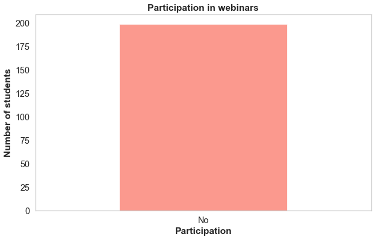

```python
plt.figure(figsize=(10, 6))
sns.set(font_scale=1.3)
sns.set_style("whitegrid", {'axes.grid' : False})

categorical_bar_plot(school_df['Webinar'], color=['salmon', 'crimson'],
                     title='Participation in webinars', xlabel='Participation')

plt.show()
```

### Plotting `'Priority Of Learning On The Internet'`

Let's check the histogram.

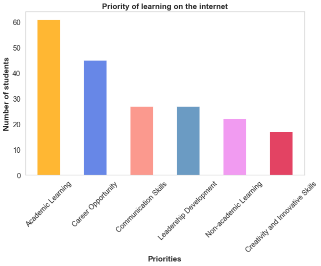

```python
plt.figure(figsize=(10, 6))
sns.set(font_scale=1.3)
sns.set_style("whitegrid", {'axes.grid' : False})

categorical_bar_plot(school_df['Priority Of Learning On The Internet'], rot=45,
                     color = ['orange', 'royalblue', 'salmon', 'steelblue', 'violet', 'crimson'],
                     title='Priority of learning on the internet', xlabel='Priorities')

plt.show()
```

Let's check the distribution of this feature against the target i.e. `'Academic Performance'`.

```
Saving figure Priority_Of_Learning_On_The_Internet_WRT_Academic_Performance
```

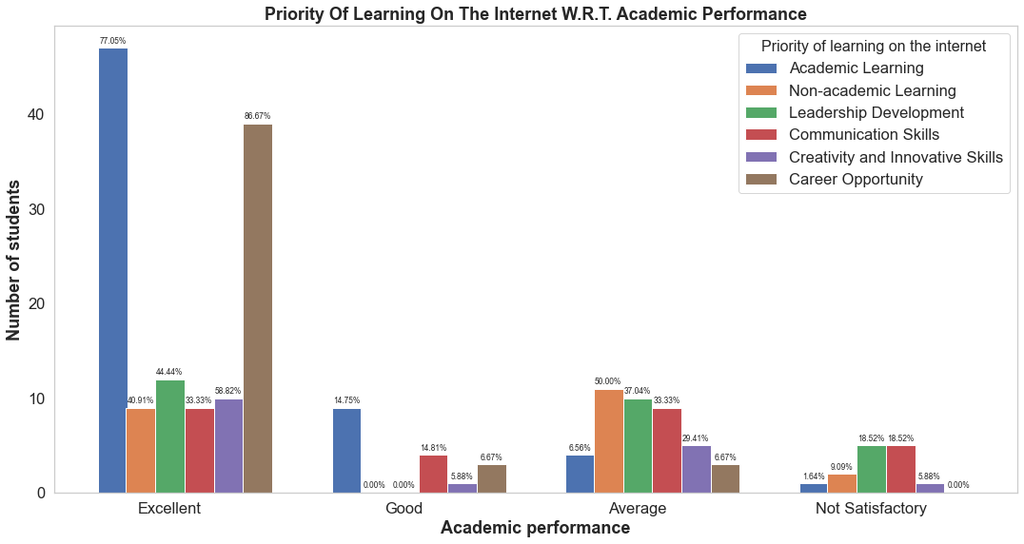

```python
sns.set(font_scale=1.5)
sns.set_style("whitegrid", {'axes.grid' : False})

dictionary = cat_vs_cat_bar_plot(school_df, 'Priority Of Learning On The Internet',
                              ['Academic Learning', 'Non-academic Learning', 'Leadership Development',
                               'Communication Skills', 'Creativity and Innovative Skills', 'Career Opportunity'])

labels = ['Excellent', 'Good', 'Average', 'Not Satisfactory']
x = np.arange(len(labels))
width = 0.25

fig, ax = plt.subplots(figsize=(15, 8))
fig.subplots_adjust(top=0.5, bottom=0.1, hspace=0.5, wspace=0.2)

rects1 = ax.bar(x - (width + 0.12), dictionary['Academic Learning'], width/2, label = 'Academic Learning')
rects2 = ax.bar(x - width, dictionary['Non-academic Learning'], width/2, label = 'Non-academic Learning')
rects3 = ax.bar(x - width/2, dictionary['Leadership Development'], width/2, label = 'Leadership Development')
rects4 = ax.bar(x, dictionary['Communication Skills'], width/2, label = 'Communication Skills')
rects5 = ax.bar(x + width/2, dictionary['Creativity and Innovative Skills'], width/2,
                label = 'Creativity and Innovative Skills')
rects6 = ax.bar(x + width, dictionary['Career Opportunity'], width/2, label = 'Career Opportunity')

ax.set_ylabel('Number of students', fontweight = 'bold')
ax.set_xlabel('Academic performance', fontweight = 'bold')
ax.set_title('Priority Of Learning On The Internet W.R.T. Academic Performance', fontweight = 'bold')
ax.set_xticks(x - width/2)
ax.set_xticklabels(labels)
ax.legend(title='Priority of learning on the internet', title_fontsize=16, loc='upper right')

sns.set(font_scale=0.7)

autolabel(rects1)
autolabel(rects2)
autolabel(rects3)
autolabel(rects4)
autolabel(rects5)
autolabel(rects6)

fig.tight_layout()

save_fig('Priority_Of_Learning_On_The_Internet_WRT_Academic_Performance')

plt.show()
```

### Plotting `'Internet Usage For Educational Purpose'`

Let's check the histogram.

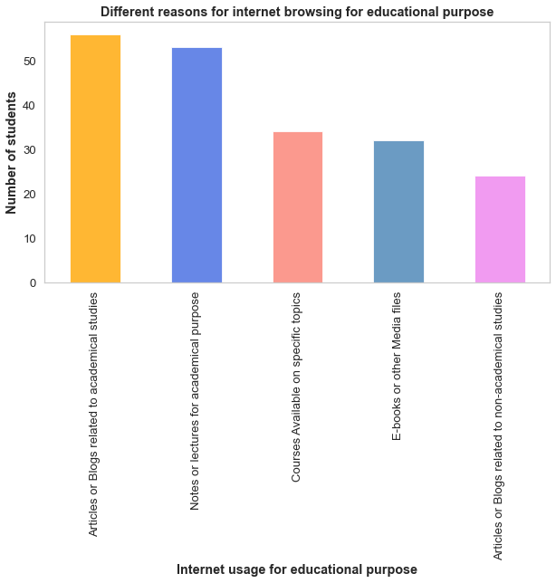

```python
plt.figure(figsize=(10, 10))
plt.subplots_adjust(top=0.5, bottom=0.1, hspace=0.5, wspace=0.2)
sns.set(font_scale=1.2)
sns.set_style("whitegrid", {'axes.grid' : False})

categorical_bar_plot(school_df['Internet Usage For Educational Purpose'], rot=90,
                     color=['orange', 'royalblue', 'salmon', 'steelblue', 'violet', 'crimson'],
                     title='Different reasons for internet browsing for educational purpose',
                     xlabel='Internet usage for educational purpose')

plt.show()
```

**Let's check the distribution of this feature against the target i.e. `'Academic Performance'`.**

```
Saving figure Internet_Usage_For_Educational_Purpose_WRT_Academic_Performance
```

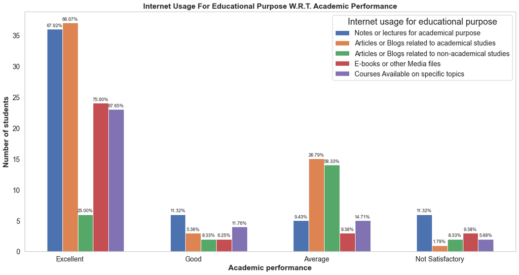

```python
sns.set(font_scale=1.3)
sns.set_style("whitegrid", {'axes.grid' : False})

dictionary = cat_vs_cat_bar_plot(school_df, 'Internet Usage For Educational Purpose',
                              school_df['Internet Usage For Educational Purpose'].value_counts().index.tolist())

labels = ['Excellent', 'Good', 'Average', 'Not Satisfactory']
x = np.arange(len(labels))
width = 0.25

fig, ax = plt.subplots(figsize=(15, 8))
fig.subplots_adjust(top=0.5, bottom=0.1, hspace=0.5, wspace=0.2)

rects1 = ax.bar(x - width, dictionary['Notes or lectures for academical purpose'],
                width/2, label = 'Notes or lectures for academical purpose')
rects2 = ax.bar(x - width/2, dictionary['Articles or Blogs related to academical studies'],
                width/2, label = 'Articles or Blogs related to academical studies')
rects3 = ax.bar(x, dictionary['Articles or Blogs related to non-academical studies'],
                width/2, label = 'Articles or Blogs related to non-academical studies')
rects4 = ax.bar(x + width/2, dictionary['E-books or other Media files'],
                width/2, label = 'E-books or other Media files')
rects5 = ax.bar(x + width, dictionary['Courses Available on specific topics'],
                width/2, label = 'Courses Available on specific topics')

ax.set_ylabel('Number of students', fontweight = 'bold')
ax.set_xlabel('Academic performance', fontweight = 'bold')
ax.set_title('Internet Usage For Educational Purpose W.R.T. Academic Performance', fontweight = 'bold')
ax.set_xticks(x - width/2)
ax.set_xticklabels(labels)
ax.legend(title='Internet usage for educational purpose', title_fontsize=18,loc='upper right')

sns.set(font_scale=0.8)

autolabel(rects1)
autolabel(rects2)
autolabel(rects3)
autolabel(rects4)
autolabel(rects5)

fig.tight_layout()

save_fig('Internet_Usage_For_Educational_Purpose_WRT_Academic_Performance')

plt.show()
```

**Let's check the distribution of this feature against the target i.e. `'Browsing Purpose'`.**

```
Saving figure Internet_Usage_For_Educational_Purpose_WRT_Browsing_Purpose
```

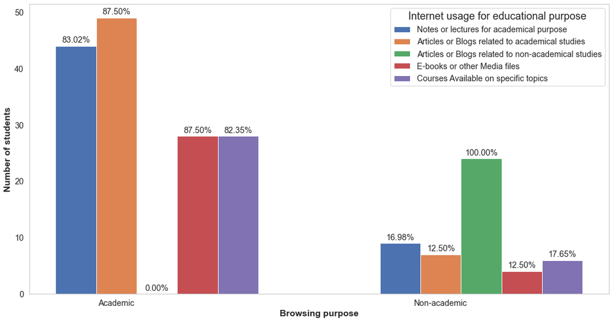

```python
sns.set(font_scale=1.3)
sns.set_style("whitegrid", {'axes.grid' : False})

dictionary = cat_vs_cat_bar_plot_browsing_purpose(school_df, 'Internet Usage For Educational Purpose',
                              school_df['Internet Usage For Educational Purpose'].value_counts().index.tolist())

labels = ['Academic', 'Non-academic']
x = np.arange(len(labels))
width = 0.25

fig, ax = plt.subplots(figsize=(15, 8))
fig.subplots_adjust(top=0.5, bottom=0.1, hspace=0.5, wspace=0.2)

rects1 = ax.bar(x - width, dictionary['Notes or lectures for academical purpose'],
                width/2, label = 'Notes or lectures for academical purpose')
rects2 = ax.bar(x - width/2, dictionary['Articles or Blogs related to academical studies'],
                width/2, label = 'Articles or Blogs related to academical studies')
rects3 = ax.bar(x, dictionary['Articles or Blogs related to non-academical studies'],
                width/2, label = 'Articles or Blogs related to non-academical studies')
rects4 = ax.bar(x + width/2, dictionary['E-books or other Media files'],
                width/2, label = 'E-books or other Media files')
rects5 = ax.bar(x + width, dictionary['Courses Available on specific topics'],
                width/2, label = 'Courses Available on specific topics')

ax.set_ylabel('Number of students', fontweight = 'bold')
ax.set_xlabel('Browsing purpose', fontweight = 'bold')
# ax.set_title('Internet Usage For Educational Purpose W.R.T. Browsing Purpose', fontweight = 'bold')
ax.set_xticks(x - width/2)
ax.set_xticklabels(labels)
ax.legend(title='Internet usage for educational purpose', title_fontsize=18, loc='upper right')

sns.set(font_scale=1.2)

autolabel(rects1)
autolabel(rects2)
autolabel(rects3)
autolabel(rects4)
autolabel(rects5)

fig.tight_layout()

save_fig('Internet_Usage_For_Educational_Purpose_WRT_Browsing_Purpose')

plt.show()
```

### Plotting `'Academic Performance'`

Let's check the histogram.

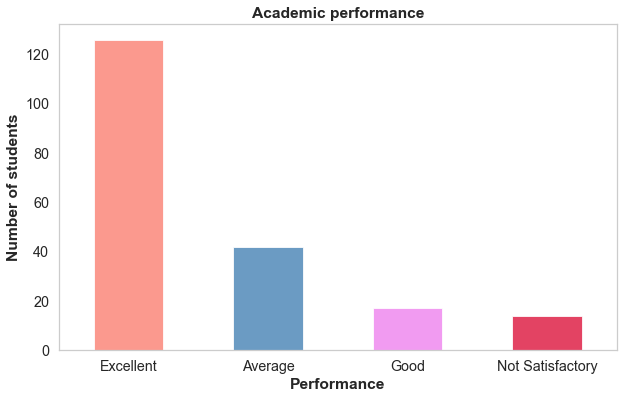

```python
plt.figure(figsize=(10, 6))
sns.set(font_scale=1.3)
sns.set_style("whitegrid", {'axes.grid' : False})


categorical_bar_plot(school_df['Academic Performance'], color=['salmon', 'steelblue', 'violet', 'crimson'],
                     title='Academic performance', xlabel='Performance')

plt.show()
```

### Plotting `'Barriers To Internet Access'`

Let's check the histogram.

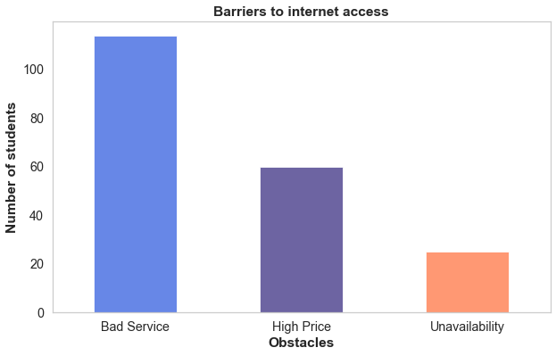

```python
plt.figure(figsize=(10, 6))
sns.set(font_scale=1.3)
sns.set_style("whitegrid", {'axes.grid' : False})


categorical_bar_plot(school_df['Barriers To Internet Access'],
                     color=['royalblue', 'darkslateblue', 'coral', 'crimson'],
                     title='Barriers to internet access', xlabel='Obstacles')

plt.show()
```

### Inspecting Age Closer

Let's define a function to make this process easier.

```python
# For Styling:
cust_palt = [
    '#111d5e', '#c70039', '#f37121', '#ffbd69', '#ffc93c'
]
```

```python
def ctn_freq(dataframe, cols, xax, hue = None, rows = 3, columns = 1):

    ''' A function for displaying numerical data frequency vs age and condition '''

    fig, axes = plt.subplots(rows, columns, figsize=(16, 12), sharex=True)
    axes = axes.flatten()

    for i, j in zip(dataframe[cols].columns, axes):
        sns.pointplot(x = xax,
                      y = i,
                      data = dataframe,
                      palette = cust_palt[:4],
                      hue = hue,
                      ax = j, ci = False)
        j.set_title(f'{str(i).capitalize()} vs. Age')


        plt.tight_layout()
```

**Now let's inspect the columns `'Total Internet Usage(hrs/day)'`, `'Duration Of Internet Usage(In Years)'`, `'Time Spent in Academic(hrs/day)'` against the column `'Age'` and also segment the distribution by the target `'Academic Performance'`.**

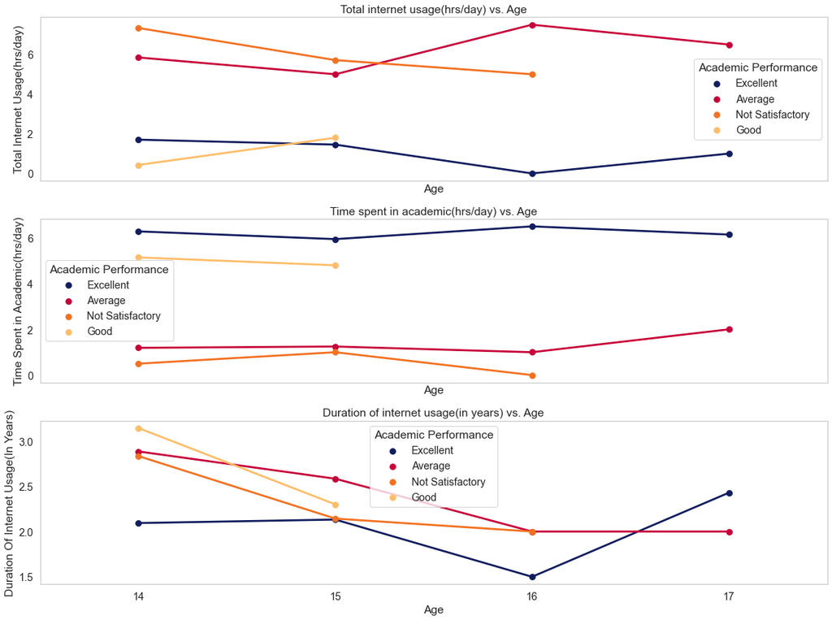

```python
ctn_freq(school_df,
         ['Total Internet Usage(hrs/day)', 'Time Spent in Academic(hrs/day)', 'Duration Of Internet Usage(In Years)'],
         'Age', hue='Academic Performance',rows=3, columns=1)
```

### Multivariate Analysis

**Multivariate analysis (MVA) is based on the principles of multivariate statistics, which involves observation and analysis of more than one statistical outcome variable at a time. Typically, MVA is used to address the situations where multiple measurements are made on each experimental unit and the relations among these measurements and their structures are important.**

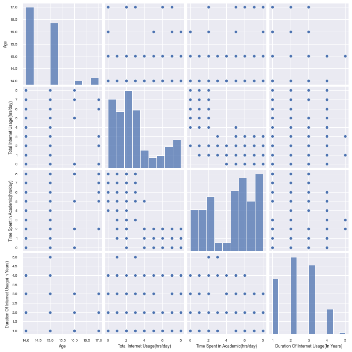

```python
# Numeric data vs each other and condition:

sns.set(font_scale = 0.7)
sns.pairplot(school_df)

plt.show()
```

**Let's add `hue = "Academic Performance"` in the `pairplot`**

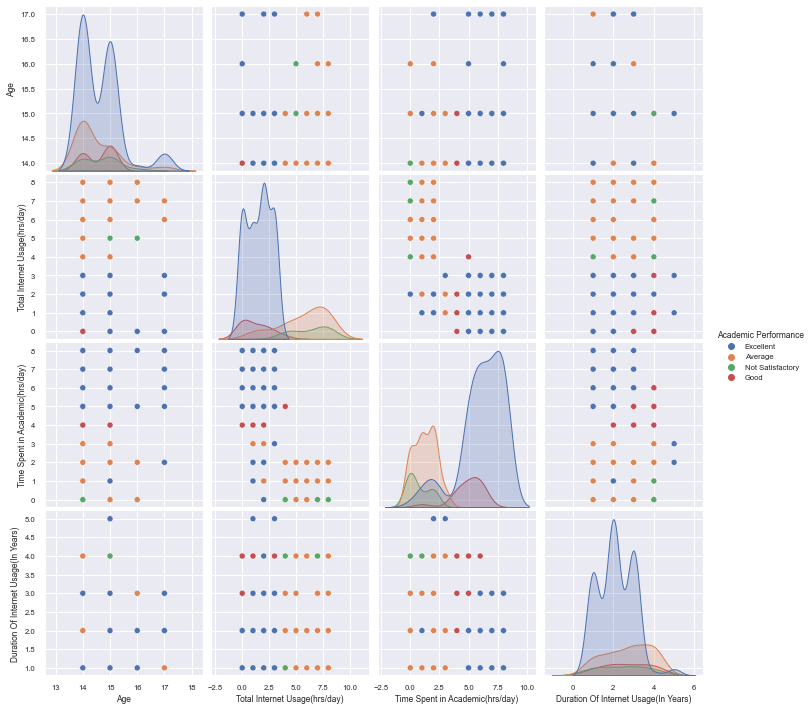

```
Saving figure Multivariate_Analysis_wrt_Academic_Performance
```

```python
sns.set(font_scale = 0.7)
sns.pairplot(school_df, hue = "Academic Performance")

# save_fig('Multivariate_Analysis_wrt_Academic_Performance')

plt.show()

save_fig('Multivariate_Analysis_wrt_Academic_Performance')
```

### Correlations

**We are going to use pearson correlation for to find linear relations between features, heatmap is decent way to show these relations.**

```python
school_df.corr(method='pearson', min_periods=1)
```

|  | Age | Total Internet Usage(hrs/day) | Time Spent in Academic(hrs/day) | Duration Of Internet Usage(In Years) |
| --- | --- | --- | --- | --- |
| Age | 1.000000 | -0.081185 | 0.015694 | -0.081835 |
| Total Internet Usage(hrs/day) | -0.081185 | 1.000000 | -0.666307 | 0.248182 |
| Time Spent in Academic(hrs/day) | 0.015694 | -0.666307 | 1.000000 | -0.258892 |
| Duration Of Internet Usage(In Years) | -0.081835 | 0.248182 | -0.258892 | 1.000000 |

```
Saving figure Correlation_heatmap_of_numerical_variables
```

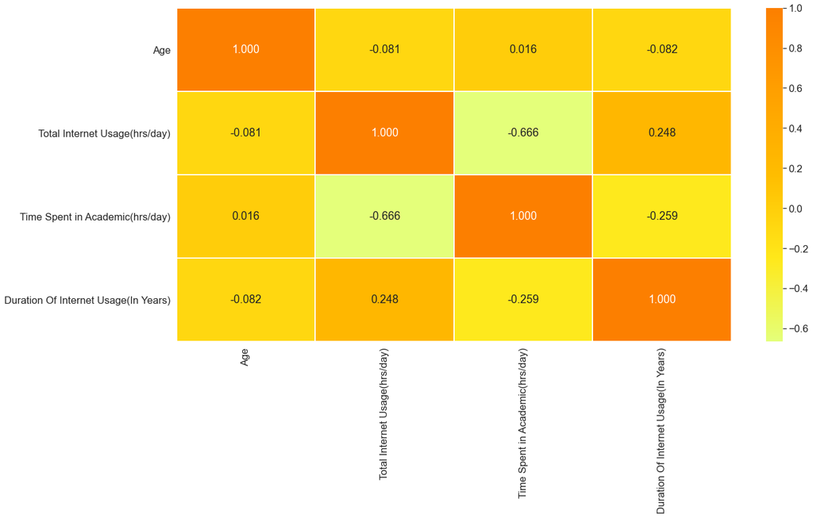

```python
# Correlation heatmap between variables:

sns.set(font_scale=1.5)

correlation_df = school_df.corr(method='pearson', min_periods=1)
mask = np.triu(correlation_df.corr())

plt.figure(figsize=(20, 12))

sns.heatmap(correlation_df,
            annot = True,
            fmt = '.3f',
            cmap = 'Wistia',
            linewidths = 1,
            cbar = True)

save_fig('Correlation_heatmap_of_numerical_variables')

plt.show()
```

## Start Predicting the Models

**Let's drop the target column `'Academic Performance'` from the main dataframe. Store the target column on a separate column first.**

```python
school_labels = school_df["Academic Performance"].copy()

school_df.drop("Academic Performance", axis = 1, inplace=True)

school_df.head()
```

|  | Gender | Age | Frequently Visited Website | Effectiveness Of Internet Usage | Devices Used For Internet Browsing | Location Of Internet Use | Household Internet Facilities | Time Of Internet Browsing | Frequency Of Internet Usage | Place Of Student's Residence | Total Internet Usage(hrs/day) | Time Spent in Academic(hrs/day) | Purpose Of Internet Use | Duration Of Internet Usage(In Years) | Browsing Purpose | Priority Of Learning On The Internet | Webinar | Internet Usage For Educational Purpose | Barriers To Internet Access |
| --- | --- | --- | --- | --- | --- | --- | --- | --- | --- | --- | --- | --- | --- | --- | --- | --- | --- | --- | --- |
| 0 | Male | 15 | Google | Very Effective | Mobile | Home | Not Connected | Night | Daily | Town | 1 | 7 | Education | 1 | Academic | Leadership Development | No | E-books or other Media files | Bad Service |
| 1 | Female | 14 | Google | Very Effective | Mobile | Home | Not Connected | Night | Daily | Village | 4 | 0 | Social Media | 3 | Non-academic | Non-academic Learning | No | Articles or Blogs related to non-academical st... | Bad Service |
| 2 | Male | 16 | Facebook | Not at all | Mobile | Home | Not Connected | Night | Weekly | Town | 5 | 0 | Entertainment | 2 | Non-academic | Leadership Development | No | Notes or lectures for academical purpose | High Price |
| 3 | Male | 14 | Facebook | Very Effective | Mobile | Home | Not Connected | Morning | Daily | Town | 0 | 6 | Education | 2 | Non-academic | Communication Skills | No | Articles or Blogs related to academical studies | Unavailability |
| 4 | Female | 14 | Whatsapp | Very Effective | Mobile | Home | Not Connected | Night | Daily | Town | 2 | 5 | Education | 3 | Academic | Non-academic Learning | No | Courses Available on specific topics | Bad Service |

```python
school_labels.head()
```

```
0           Excellent
1             Average
2    Not Satisfactory
3           Excellent
4           Excellent
Name: Academic Performance, dtype: object
```

**Let's separate the numerical and categorical columns for preprocessing. Let's check which columns are numerical and which are categorical.**

```python
school_df.info()
```

```
<class 'pandas.core.frame.DataFrame'>
RangeIndex: 199 entries, 0 to 198
Data columns (total 19 columns):
 #   Column                                  Non-Null Count  Dtype
---  ------                                  --------------  -----
 0   Gender                                  199 non-null    object
 1   Age                                     199 non-null    int64
 2   Frequently Visited Website              199 non-null    object
 3   Effectiveness Of Internet Usage         199 non-null    object
 4   Devices Used For Internet Browsing      199 non-null    object
 5   Location Of Internet Use                199 non-null    object
 6   Household Internet Facilities           199 non-null    object
 7   Time Of Internet Browsing               199 non-null    object
 8   Frequency Of Internet Usage             199 non-null    object
 9   Place Of Student's Residence            199 non-null    object
 10  Total Internet Usage(hrs/day)           199 non-null    int64
 11  Time Spent in Academic(hrs/day)         199 non-null    int64
 12  Purpose Of Internet Use                 199 non-null    object
 13  Duration Of Internet Usage(In Years)    199 non-null    int64
 14  Browsing Purpose                        199 non-null    object
 15  Priority Of Learning On The Internet    199 non-null    object
 16  Webinar                                 199 non-null    object
 17  Internet Usage For Educational Purpose  199 non-null    object
 18  Barriers To Internet Access             199 non-null    object
dtypes: int64(4), object(15)
memory usage: 29.7+ KB
```

**The columns `'Age'`, `'Total Internet Usage(hrs/day)'`, `'Time Spent in Academic(hrs/day)'`, `'Duration Of Internet Usage(In Years)'` contain numerical values. Let's separate them from the main dataframe.**

```python
school_cat = school_df.drop(['Age', 'Total Internet Usage(hrs/day)','Time Spent in Academic(hrs/day)',
                            'Duration Of Internet Usage(In Years)'], axis = 1)

school_cat.head()
```

|  | Gender | Frequently Visited Website | Effectiveness Of Internet Usage | Devices Used For Internet Browsing | Location Of Internet Use | Household Internet Facilities | Time Of Internet Browsing | Frequency Of Internet Usage | Place Of Student's Residence | Purpose Of Internet Use | Browsing Purpose | Priority Of Learning On The Internet | Webinar | Internet Usage For Educational Purpose | Barriers To Internet Access |
| --- | --- | --- | --- | --- | --- | --- | --- | --- | --- | --- | --- | --- | --- | --- | --- |
| 0 | Male | Google | Very Effective | Mobile | Home | Not Connected | Night | Daily | Town | Education | Academic | Leadership Development | No | E-books or other Media files | Bad Service |
| 1 | Female | Google | Very Effective | Mobile | Home | Not Connected | Night | Daily | Village | Social Media | Non-academic | Non-academic Learning | No | Articles or Blogs related to non-academical st... | Bad Service |
| 2 | Male | Facebook | Not at all | Mobile | Home | Not Connected | Night | Weekly | Town | Entertainment | Non-academic | Leadership Development | No | Notes or lectures for academical purpose | High Price |
| 3 | Male | Facebook | Very Effective | Mobile | Home | Not Connected | Morning | Daily | Town | Education | Non-academic | Communication Skills | No | Articles or Blogs related to academical studies | Unavailability |
| 4 | Female | Whatsapp | Very Effective | Mobile | Home | Not Connected | Night | Daily | Town | Education | Academic | Non-academic Learning | No | Courses Available on specific topics | Bad Service |

```python
school_cat.info()
```

```
<class 'pandas.core.frame.DataFrame'>
RangeIndex: 199 entries, 0 to 198
Data columns (total 15 columns):
 #   Column                                  Non-Null Count  Dtype
---  ------                                  --------------  -----
 0   Gender                                  199 non-null    object
 1   Frequently Visited Website              199 non-null    object
 2   Effectiveness Of Internet Usage         199 non-null    object
 3   Devices Used For Internet Browsing      199 non-null    object
 4   Location Of Internet Use                199 non-null    object
 5   Household Internet Facilities           199 non-null    object
 6   Time Of Internet Browsing               199 non-null    object
 7   Frequency Of Internet Usage             199 non-null    object
 8   Place Of Student's Residence            199 non-null    object
 9   Purpose Of Internet Use                 199 non-null    object
 10  Browsing Purpose                        199 non-null    object
 11  Priority Of Learning On The Internet    199 non-null    object
 12  Webinar                                 199 non-null    object
 13  Internet Usage For Educational Purpose  199 non-null    object
 14  Barriers To Internet Access             199 non-null    object
dtypes: object(15)
memory usage: 23.4+ KB
```

**Store the numerical attributes in a separate variable.**

```python
school_num = school_df[['Age', 'Total Internet Usage(hrs/day)','Time Spent in Academic(hrs/day)',
                       'Duration Of Internet Usage(In Years)']].copy()

school_num.head()
```

|  | Age | Total Internet Usage(hrs/day) | Time Spent in Academic(hrs/day) | Duration Of Internet Usage(In Years) |
| --- | --- | --- | --- | --- |
| 0 | 15 | 1 | 7 | 1 |
| 1 | 14 | 4 | 0 | 3 |
| 2 | 16 | 5 | 0 | 2 |
| 3 | 14 | 0 | 6 | 2 |
| 4 | 14 | 2 | 5 | 3 |

```python
school_num.info()
```

```
<class 'pandas.core.frame.DataFrame'>
RangeIndex: 199 entries, 0 to 198
Data columns (total 4 columns):
 #   Column                                Non-Null Count  Dtype
---  ------                                --------------  -----
 0   Age                                   199 non-null    int64
 1   Total Internet Usage(hrs/day)         199 non-null    int64
 2   Time Spent in Academic(hrs/day)       199 non-null    int64
 3   Duration Of Internet Usage(In Years)  199 non-null    int64
dtypes: int64(4)
memory usage: 6.3 KB
```

**Let's integerize the categorical values in the dataset `school_cat`. We'll use the `LabelEncoder` from the `sklearn.preprocessing`.**

```python
from sklearn import preprocessing

# label_encoder object knows how to understand word labels.
label_encoder = preprocessing.LabelEncoder()

temp_df_cat = school_cat.apply(preprocessing.LabelEncoder().fit_transform)

temp_df_cat.head()
```

|  | Gender | Frequently Visited Website | Effectiveness Of Internet Usage | Devices Used For Internet Browsing | Location Of Internet Use | Household Internet Facilities | Time Of Internet Browsing | Frequency Of Internet Usage | Place Of Student's Residence | Purpose Of Internet Use | Browsing Purpose | Priority Of Learning On The Internet | Webinar | Internet Usage For Educational Purpose | Barriers To Internet Access |
| --- | --- | --- | --- | --- | --- | --- | --- | --- | --- | --- | --- | --- | --- | --- | --- |
| 0 | 1 | 1 | 2 | 2 | 1 | 1 | 3 | 0 | 1 | 0 | 0 | 4 | 0 | 3 | 0 |
| 1 | 0 | 1 | 2 | 2 | 1 | 1 | 3 | 0 | 2 | 4 | 1 | 5 | 0 | 1 | 0 |
| 2 | 1 | 0 | 0 | 2 | 1 | 1 | 3 | 2 | 1 | 1 | 1 | 4 | 0 | 4 | 1 |
| 3 | 1 | 0 | 2 | 2 | 1 | 1 | 2 | 0 | 1 | 0 | 1 | 2 | 0 | 0 | 2 |
| 4 | 0 | 2 | 2 | 2 | 1 | 1 | 3 | 0 | 1 | 0 | 0 | 5 | 0 | 2 | 0 |

**Let's Normalize the dataset using `sklearn`'s `normalize` function. But the dataset seems to perform better without normalization.**

```python
# from sklearn.preprocessing import normalize


# temp_df_normalized = normalize(college_num)
# temp_df_num = pd.DataFrame(temp_df_normalized, columns = list(college_num))

# temp_df_num.head()
```

**Let's combine the preprocessed numerical and categorical part of the dataset.**

```python
# Place the DataFrames side by side

X = pd.concat([school_num, temp_df_cat], axis=1)
y = school_labels

X.head()
```

|  | Age | Total Internet Usage(hrs/day) | Time Spent in Academic(hrs/day) | Duration Of Internet Usage(In Years) | Gender | Frequently Visited Website | Effectiveness Of Internet Usage | Devices Used For Internet Browsing | Location Of Internet Use | Household Internet Facilities | Time Of Internet Browsing | Frequency Of Internet Usage | Place Of Student's Residence | Purpose Of Internet Use | Browsing Purpose | Priority Of Learning On The Internet | Webinar | Internet Usage For Educational Purpose | Barriers To Internet Access |
| --- | --- | --- | --- | --- | --- | --- | --- | --- | --- | --- | --- | --- | --- | --- | --- | --- | --- | --- | --- |
| 0 | 15 | 1 | 7 | 1 | 1 | 1 | 2 | 2 | 1 | 1 | 3 | 0 | 1 | 0 | 0 | 4 | 0 | 3 | 0 |
| 1 | 14 | 4 | 0 | 3 | 0 | 1 | 2 | 2 | 1 | 1 | 3 | 0 | 2 | 4 | 1 | 5 | 0 | 1 | 0 |
| 2 | 16 | 5 | 0 | 2 | 1 | 0 | 0 | 2 | 1 | 1 | 3 | 2 | 1 | 1 | 1 | 4 | 0 | 4 | 1 |
| 3 | 14 | 0 | 6 | 2 | 1 | 0 | 2 | 2 | 1 | 1 | 2 | 0 | 1 | 0 | 1 | 2 | 0 | 0 | 2 |
| 4 | 14 | 2 | 5 | 3 | 0 | 2 | 2 | 2 | 1 | 1 | 3 | 0 | 1 | 0 | 0 | 5 | 0 | 2 | 0 |

**Split the dataset for training and testing purposes. We'll use `sklearn`'s `train_test_split` function to do this.**

```python
# split a dataset into train and test sets
from sklearn.model_selection import train_test_split


# split into train test sets
X_train, X_test, y_train, y_test = train_test_split(X, y, test_size=0.30)

print(X_train.shape, X_test.shape, y_train.shape, y_test.shape)
```

```
(139, 19) (60, 19) (139,) (60,)
```

# Implementing Machine Learning Algorithms For Classification

## Stochastic Gradient Descent

**Let's start with Stochastic Gradient Descent classifier. We'll use `sklearn`'s `SGDClassifier` to do this. After training the classifier, we'll check the model accuracy score.**

```python
from sklearn.linear_model import SGDClassifier
from sklearn import metrics


sgd_clf = SGDClassifier(max_iter=1000, tol=1e-3, random_state=42)

sgd_clf.fit(X_train, y_train)

score = sgd_clf.score(X_train, y_train)
print("Training score: ", score)
```

```
Training score:  0.8992805755395683
```

**Let's check the confusion matrix and classification report of this model.**

```python
from sklearn.metrics import confusion_matrix
from sklearn.metrics import classification_report


y_pred_sgd = sgd_clf.predict(X_test)

conf_mat = confusion_matrix(y_test, y_pred_sgd)
class_report = classification_report(y_test, y_pred_sgd)


print("Accuracy:", metrics.accuracy_score(y_test, y_pred_sgd))

print(conf_mat)
print(class_report)
```

```
Accuracy: 0.7333333333333333
[[10  3  0  2]
 [ 0 32  0  0]
 [ 0  9  0  0]
 [ 2  0  0  2]]
                  precision    recall  f1-score   support

         Average       0.83      0.67      0.74        15
       Excellent       0.73      1.00      0.84        32
            Good       0.00      0.00      0.00         9
Not Satisfactory       0.50      0.50      0.50         4

        accuracy                           0.73        60
       macro avg       0.52      0.54      0.52        60
    weighted avg       0.63      0.73      0.67        60
```

**Let's perform cross validation using this model. We'll `KFold` for this purpose.**

```python
from sklearn.model_selection import cross_val_score
from sklearn.model_selection import KFold


cv_sgd = KFold(n_splits=10, shuffle=True, random_state=42)
cross_val_score(sgd_clf, X_train, y_train, cv=cv_sgd, scoring="accuracy", n_jobs=-1)
```

```
array([0.78571429, 0.78571429, 0.71428571, 0.85714286, 0.85714286,
       0.71428571, 0.78571429, 0.92857143, 0.85714286, 0.84615385])
```

```python
scores = cross_val_score(sgd_clf, X_test, y_test, cv=cv_sgd, scoring="accuracy", n_jobs=-1)
print('Accuracy: %.3f (%.3f)' % (np.mean(scores), np.std(scores)))
```

```
Accuracy: 0.667 (0.258)
```

**Let's check the score.**

```python
scores = cross_val_score(sgd_clf, X_test, y_test, cv=3, scoring="accuracy", n_jobs=-1)
print('Accuracy: %.3f (%.3f)' % (np.mean(scores), np.std(scores)))
```

```
Accuracy: 0.567 (0.155)
```

**Let's plot the training accuracy curve. But first we'll train and predict the model with `max_iter` in the range of (5, 300)**

```python
m_iter = []
training = []
test = []
scores = {}

max_i = [5, 10, 15, 20, 25, 30, 35, 40, 45, 50, 55, 60, 70, 80, 90, 100, 130, 150, 170, 200, 250, 300]

for i in range(len(max_i)):
    clf = SGDClassifier(max_iter=max_i[i], tol=1e-3, random_state=42)

    clf.fit(X_train, y_train)

    training_score = clf.score(X_train, y_train)
    test_score = clf.score(X_test, y_test)
    m_iter.append(max_i[i])

    training.append(training_score)
    test.append(test_score)
    scores[i] = [training_score, test_score]
```

**Let's check the `scores` variable.**

```python
for keys, values in scores.items():
    print(keys, ':', values)
```

```
0 : [0.8848920863309353, 0.75]
1 : [0.841726618705036, 0.7]
2 : [0.8633093525179856, 0.6833333333333333]
3 : [0.841726618705036, 0.6833333333333333]
4 : [0.8992805755395683, 0.7333333333333333]
5 : [0.9064748201438849, 0.7166666666666667]
6 : [0.8992805755395683, 0.7333333333333333]
7 : [0.8992805755395683, 0.7333333333333333]
8 : [0.8992805755395683, 0.7333333333333333]
9 : [0.8992805755395683, 0.7333333333333333]
10 : [0.8992805755395683, 0.7333333333333333]
11 : [0.8992805755395683, 0.7333333333333333]
12 : [0.8992805755395683, 0.7333333333333333]
13 : [0.8992805755395683, 0.7333333333333333]
14 : [0.8992805755395683, 0.7333333333333333]
15 : [0.8992805755395683, 0.7333333333333333]
16 : [0.8992805755395683, 0.7333333333333333]
17 : [0.8992805755395683, 0.7333333333333333]
18 : [0.8992805755395683, 0.7333333333333333]
19 : [0.8992805755395683, 0.7333333333333333]
20 : [0.8992805755395683, 0.7333333333333333]
21 : [0.8992805755395683, 0.7333333333333333]
```

```python
# plt.figure(figsize=(10, 4))
# sns.set(font_scale=1.3)
# sns.set_style("whitegrid", {'axes.grid' : False})

# ax = sns.stripplot(m_iter, training);
# ax.set(xlabel ='max iteration', ylabel ='Training Score')

# plt.show()
```

```python
# plt.figure(figsize=(10, 4))
# sns.set(font_scale=1.3)
# sns.set_style("whitegrid", {'axes.grid' : False})

# ax = sns.stripplot(m_iter, test);
# ax.set(xlabel ='max iteration', ylabel ='Testing Score')

# plt.show()
```

**Let's combine the two scores together to compare the two.**

```
Saving figure SGDClassifier_training_testing_scores
```

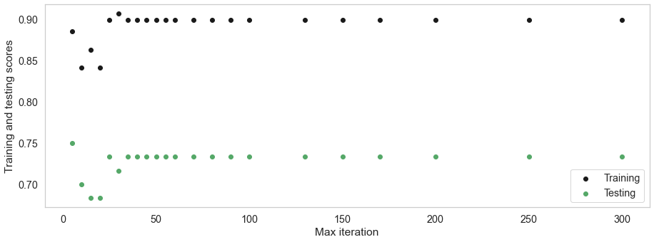

```python
plt.figure(figsize=(13, 5))
sns.set(font_scale=1.3)
sns.set_style("whitegrid", {'axes.grid' : False})

plt.scatter(m_iter, training, color ='k')
plt.scatter(m_iter, test, color ='g')

plt.ylabel('Training and testing scores')
plt.xlabel('Max iteration')
plt.legend(labels=['Training', 'Testing'])

save_fig('SGDClassifier_training_testing_scores')
plt.show()
```

## Decision Tree

**Let's start with Decision Tree classifier. We'll use `sklearn`'s `DecisionTreeClassifier` to do this. After training the classifier, we'll check the model accuracy score.**

```python
from sklearn.tree import DecisionTreeClassifier
from sklearn import metrics

dec_tree_clf = DecisionTreeClassifier(max_depth=9, max_leaf_nodes = 50, random_state=42)

dec_tree_clf.fit(X_train, y_train)

score = dec_tree_clf.score(X_train, y_train)
print("Training score: ", score)
```

```
Training score:  1.0
```

**Let's check the confusion matrix and classification report of this model.**

```python
from sklearn.metrics import confusion_matrix
from sklearn.metrics import classification_report


y_pred_dec_tree = dec_tree_clf.predict(X_test)

conf_mat = confusion_matrix(y_test, y_pred_dec_tree)
class_report = classification_report(y_test, y_pred_dec_tree)


print("Accuracy:", metrics.accuracy_score(y_test, y_pred_dec_tree))

print(conf_mat)
print(class_report)
```

```
Accuracy: 0.75
[[ 9  2  0  4]
 [ 0 32  0  0]
 [ 1  5  3  0]
 [ 3  0  0  1]]
                  precision    recall  f1-score   support

         Average       0.69      0.60      0.64        15
       Excellent       0.82      1.00      0.90        32
            Good       1.00      0.33      0.50         9
Not Satisfactory       0.20      0.25      0.22         4

        accuracy                           0.75        60
       macro avg       0.68      0.55      0.57        60
    weighted avg       0.77      0.75      0.73        60
```

**Let's perform cross validation using this model. We'll `KFold` for this purpose.**

```python
from sklearn.model_selection import cross_val_score
from sklearn.model_selection import KFold


cv_dec_tree = KFold(n_splits=10, shuffle=True, random_state=42)
cross_val_score(dec_tree_clf, X_train, y_train, cv=cv_dec_tree, scoring="accuracy", n_jobs=-1)
```

```
array([0.85714286, 0.71428571, 0.64285714, 1.        , 0.78571429,
       0.78571429, 0.71428571, 0.92857143, 0.71428571, 0.76923077])
```

```python
scores = cross_val_score(dec_tree_clf, X_test, y_test, cv=cv_dec_tree, scoring="accuracy", n_jobs=-1)
print('Accuracy: %.3f (%.3f)' % (np.mean(scores), np.std(scores)))
```

```
Accuracy: 0.567 (0.226)
```

**Let's check the score.**

```python
scores = cross_val_score(dec_tree_clf, X_test, y_test, cv=3, scoring="accuracy", n_jobs=-1)
print('Accuracy: %.3f (%.3f)' % (np.mean(scores), np.std(scores)))
```

```
Accuracy: 0.617 (0.118)
```

**Let's plot the training accuracy curve. But first we'll train and predict the model with `max_depth` in the range of (1, 27)**

```python
m_depth = []
training = []
test = []
scores = {}

max_d = [1, 2, 3, 4, 5, 6, 7, 8, 9, 10, 11, 12, 13, 14, 15, 16, 17, 18, 19, 20, 21, 22, 23, 24, 25, 26, 27]

for i in range(len(max_d)):
    clf = DecisionTreeClassifier(max_depth=max_d[i], max_leaf_nodes = 50, random_state=42)

    clf.fit(X_train, y_train)

    training_score = clf.score(X_train, y_train)
    test_score = clf.score(X_test, y_test)
    m_depth.append(max_d[i])

    training.append(training_score)
    test.append(test_score)
    scores[i] = [training_score, test_score]
```

**Let's check the `scores` variable.**

```python
for keys, values in scores.items():
    print(keys, ':', values)
```

```
0 : [0.8489208633093526, 0.7333333333333333]
1 : [0.8705035971223022, 0.7]
2 : [0.9064748201438849, 0.7666666666666667]
3 : [0.935251798561151, 0.7333333333333333]
4 : [0.9640287769784173, 0.7333333333333333]
5 : [0.9856115107913669, 0.7666666666666667]
6 : [1.0, 0.75]
7 : [1.0, 0.75]
8 : [1.0, 0.75]
9 : [1.0, 0.75]
10 : [1.0, 0.75]
11 : [1.0, 0.75]
12 : [1.0, 0.75]
13 : [1.0, 0.75]
14 : [1.0, 0.75]
15 : [1.0, 0.75]
16 : [1.0, 0.75]
17 : [1.0, 0.75]
18 : [1.0, 0.75]
19 : [1.0, 0.75]
20 : [1.0, 0.75]
21 : [1.0, 0.75]
22 : [1.0, 0.75]
23 : [1.0, 0.75]
24 : [1.0, 0.75]
25 : [1.0, 0.75]
26 : [1.0, 0.75]
```

**Finally, let's plot the training and testing scores together so that we can compare the two.**

```
Saving figure DecisionTreeClassifier_training_testing_scores
```

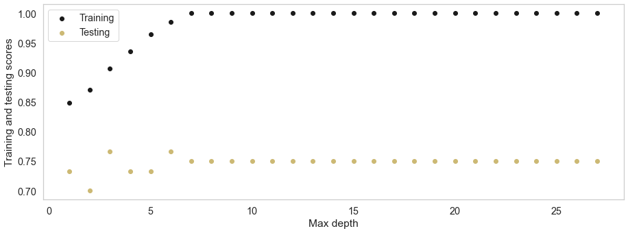

```python
plt.figure(figsize=(13, 5))
sns.set(font_scale=1.3)
sns.set_style("whitegrid", {'axes.grid' : False})

plt.scatter(m_depth, training, color ='k')
plt.scatter(m_depth, test, color ='y')

plt.ylabel('Training and testing scores')
plt.xlabel('Max depth')
plt.legend(labels=['Training', 'Testing'])

save_fig('DecisionTreeClassifier_training_testing_scores')
plt.show()
```

## Logistic Regression

**Let's start with Logistic Regression classifier. We'll use `sklearn`'s `LogisticRegression` to do this. After training the classifier, we'll check the model accuracy score.**

```python
from sklearn.linear_model import LogisticRegression
from sklearn import metrics

log_reg = LogisticRegression(max_iter=1000, multi_class='multinomial', random_state=42, warm_start=False)

log_reg.fit(X_train, y_train)

score = log_reg.score(X_train, y_train)
print("Training score: ", score)
```

```
Training score:  0.9424460431654677
```

**Let's check the confusion matrix and classification report of this model.**

```python
from sklearn.metrics import confusion_matrix
from sklearn.metrics import classification_report


y_pred_log = log_reg.predict(X_test)

conf_mat = confusion_matrix(y_test, y_pred_log)
class_report = classification_report(y_test, y_pred_log)


print("Accuracy:", metrics.accuracy_score(y_test, y_pred_log))

print(conf_mat)
print(class_report)
```

```
Accuracy: 0.7333333333333333
[[10  2  0  3]
 [ 0 32  0  0]
 [ 0  9  0  0]
 [ 2  0  0  2]]
                  precision    recall  f1-score   support

         Average       0.83      0.67      0.74        15
       Excellent       0.74      1.00      0.85        32
            Good       0.00      0.00      0.00         9
Not Satisfactory       0.40      0.50      0.44         4

        accuracy                           0.73        60
       macro avg       0.49      0.54      0.51        60
    weighted avg       0.63      0.73      0.67        60
```

**Let's perform cross validation using this model. We'll `KFold` for this purpose.**

```python
from sklearn.model_selection import cross_val_score
from sklearn.model_selection import KFold


cv_log_reg = KFold(n_splits=10, shuffle=True, random_state=42)
cross_val_score(log_reg, X_train, y_train, cv=cv_log_reg, scoring="accuracy", n_jobs=-1)
```

```
array([0.92857143, 0.64285714, 0.78571429, 0.85714286, 0.78571429,
       0.92857143, 0.71428571, 0.92857143, 0.85714286, 0.84615385])
```

```python
scores = cross_val_score(log_reg, X_test, y_test, cv=cv_log_reg, scoring="accuracy", n_jobs=-1)
print('Accuracy: %.3f (%.3f)' % (np.mean(scores), np.std(scores)))
```

```
Accuracy: 0.650 (0.117)
```

**Let's check the score.**

```python
scores = cross_val_score(log_reg, X_test, y_test, cv=3, scoring="accuracy", n_jobs=-1)
print('Accuracy: %.3f (%.3f)' % (np.mean(scores), np.std(scores)))
```

```
Accuracy: 0.583 (0.143)
```

```python
m_iter = []
training = []
test = []
scores = {}

max_i = [50, 60, 80, 100, 200, 300, 400, 500, 600, 700, 800, 900, 1000,
         1100, 1200, 1300, 1400, 1500]

for i in range(len(max_i)):
    clf = LogisticRegression(max_iter=max_i[i], multi_class='multinomial', random_state=42, warm_start=False)

    clf.fit(X_train, y_train)

    training_score = clf.score(X_train, y_train)
    test_score = clf.score(X_test, y_test)
    m_iter.append(max_i[i])

    training.append(training_score)
    test.append(test_score)
    scores[i] = [training_score, test_score]
```

[output not shown]

[output cut: 9 more lines]

[output not shown]

**Let's check the `scores` variable.**

```python
for keys, values in scores.items():
    print(keys, ':', values)
```

```
0 : [0.9280575539568345, 0.7333333333333333]
1 : [0.9280575539568345, 0.75]
2 : [0.9280575539568345, 0.7333333333333333]
3 : [0.9280575539568345, 0.7333333333333333]
4 : [0.9424460431654677, 0.7333333333333333]
5 : [0.9424460431654677, 0.7333333333333333]
6 : [0.9424460431654677, 0.7333333333333333]
7 : [0.9424460431654677, 0.7333333333333333]
8 : [0.9424460431654677, 0.7333333333333333]
9 : [0.9424460431654677, 0.7333333333333333]
10 : [0.9424460431654677, 0.7333333333333333]
11 : [0.9424460431654677, 0.7333333333333333]
12 : [0.9424460431654677, 0.7333333333333333]
13 : [0.9424460431654677, 0.7333333333333333]
14 : [0.9424460431654677, 0.7333333333333333]
15 : [0.9424460431654677, 0.7333333333333333]
16 : [0.9424460431654677, 0.7333333333333333]
17 : [0.9424460431654677, 0.7333333333333333]
```

**Finally, let's plot the training and testing scores together so that we can compare the two.**

```
Saving figure LogisticRegression_training_testing_scores
```

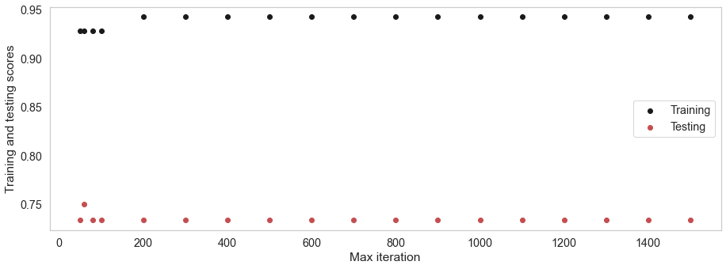

```python
plt.figure(figsize=(13, 5))
sns.set(font_scale=1.3)
sns.set_style("whitegrid", {'axes.grid' : False})

plt.scatter(m_iter, training, color ='k')
plt.scatter(m_iter, test, color ='r')

plt.ylabel('Training and testing scores')
plt.xlabel('Max iteration')
plt.legend(labels=['Training', 'Testing'])

save_fig('LogisticRegression_training_testing_scores')
plt.show()
```

## Random Forest

**Let's start with Random Forest classifier. We'll use `sklearn`'s `RandomForestClassifier` to do this. After training the classifier, we'll check the model accuracy score.**

```python
from sklearn.ensemble import RandomForestClassifier
from sklearn import metrics

random_for_clf = RandomForestClassifier(n_estimators=30, max_depth=50, random_state=42, warm_start=False)

random_for_clf.fit(X_train, y_train)

score = random_for_clf.score(X_train, y_train)
print("Training score: ", score)
```

```
Training score:  1.0
```

**Let's check the confusion matrix and classification report of this model.**

```python
from sklearn.metrics import confusion_matrix
from sklearn.metrics import classification_report


y_pred_rand = random_for_clf.predict(X_test)

conf_mat = confusion_matrix(y_test, y_pred_rand)
class_report = classification_report(y_test, y_pred_rand)


print("Accuracy:", metrics.accuracy_score(y_test, y_pred_rand))

print(conf_mat)
print(class_report)
```

```
Accuracy: 0.75
[[12  2  0  1]
 [ 1 31  0  0]
 [ 0  9  0  0]
 [ 2  0  0  2]]
                  precision    recall  f1-score   support

         Average       0.80      0.80      0.80        15
       Excellent       0.74      0.97      0.84        32
            Good       0.00      0.00      0.00         9
Not Satisfactory       0.67      0.50      0.57         4

        accuracy                           0.75        60
       macro avg       0.55      0.57      0.55        60
    weighted avg       0.64      0.75      0.68        60
```

**Let's perform cross validation using this model. We'll `KFold` for this purpose.**

```python
from sklearn.model_selection import cross_val_score
from sklearn.model_selection import KFold


cv_rand_for = KFold(n_splits=10, shuffle=True, random_state=42)
cross_val_score(random_for_clf, X_train, y_train, cv=cv_rand_for, scoring="accuracy", n_jobs=-1)
```

```
array([0.85714286, 0.71428571, 0.78571429, 0.92857143, 0.92857143,
       0.85714286, 0.71428571, 0.92857143, 0.85714286, 0.84615385])
```

```python
scores = cross_val_score(random_for_clf, X_test, y_test, cv=cv_rand_for, scoring="accuracy", n_jobs=-1)
print('Accuracy: %.3f (%.3f)' % (np.mean(scores), np.std(scores)))
```

```
Accuracy: 0.667 (0.183)
```

**Let's check the score.**

```python
scores = cross_val_score(random_for_clf, X_test, y_test, cv=3, scoring="accuracy", n_jobs=-1)
print('Accuracy: %.3f (%.3f)' % (np.mean(scores), np.std(scores)))
```

```
Accuracy: 0.717 (0.047)
```

```python
n_estimate = []
training = []
test = []
scores = {}

for i in range(1, 40):
    clf = RandomForestClassifier(n_estimators=i, max_depth=50, random_state=42, warm_start=False)

    clf.fit(X_train, y_train)

    training_score = clf.score(X_train, y_train)
    test_score = clf.score(X_test, y_test)
    n_estimate.append(i)

    training.append(training_score)
    test.append(test_score)
    scores[i] = [training_score, test_score]
```

**Let's check the `scores` variable.**

```python
for keys, values in scores.items():
    print(keys, ':', values)
```

```
1 : [0.9280575539568345, 0.65]
2 : [0.935251798561151, 0.6833333333333333]
3 : [0.9712230215827338, 0.7166666666666667]
4 : [0.9568345323741008, 0.7333333333333333]
5 : [0.9640287769784173, 0.7333333333333333]
6 : [0.9640287769784173, 0.7333333333333333]
7 : [0.9712230215827338, 0.75]
8 : [0.9640287769784173, 0.75]
9 : [0.9784172661870504, 0.7333333333333333]
10 : [0.9712230215827338, 0.7333333333333333]
11 : [0.9712230215827338, 0.7333333333333333]
12 : [0.9712230215827338, 0.7333333333333333]
13 : [0.9856115107913669, 0.7333333333333333]
14 : [0.9784172661870504, 0.75]
15 : [0.9928057553956835, 0.75]
```

[output cut: 24 more lines]

**Finally, let's plot the training and testing scores together so that we can compare the two.**

```
Saving figure RandomForestClassifier_training_testing_scores
```

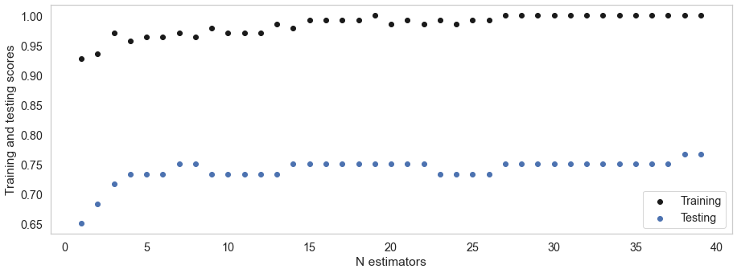

```python
plt.figure(figsize=(13, 5))
sns.set(font_scale=1.3)
sns.set_style("whitegrid", {'axes.grid' : False})

plt.scatter(n_estimate, training, color ='k')
plt.scatter(n_estimate, test, color ='b')

plt.ylabel('Training and testing scores')
plt.xlabel('N estimators')
plt.legend(labels=['Training', 'Testing'])

save_fig('RandomForestClassifier_training_testing_scores')
plt.show()
```

## Naive Bayes

```python
### 1.GaussianNB
from sklearn.naive_bayes import GaussianNB
from sklearn import metrics


gaussNB_clf = GaussianNB()

gaussNB_clf.fit(X_train, y_train)

score = gaussNB_clf.score(X_train, y_train)
print("Training score: ", score)
```

```
Training score:  0.4676258992805755
```

```python
### 2.MultinomialNB
from sklearn.naive_bayes import MultinomialNB


multinomNB_clf = MultinomialNB()

multinomNB_clf.fit(X_train, y_train)

score = multinomNB_clf.score(X_train, y_train)
print("Training score: ", score)
```

```
Training score:  0.8920863309352518
```

**`MultinomialNB` performs better than the others.**

**Let's check the confusion matrix and classification report of this model.**

```python
from sklearn.metrics import confusion_matrix
from sklearn.metrics import classification_report


y_pred_nb = multinomNB_clf.predict(X_test)

conf_mat = confusion_matrix(y_test, y_pred_nb)
class_report = classification_report(y_test, y_pred_nb)


print("Accuracy:", metrics.accuracy_score(y_test, y_pred_nb))

print(conf_mat)
print(class_report)
```

```
Accuracy: 0.7333333333333333
[[11  2  0  2]
 [ 1 31  0  0]
 [ 0  9  0  0]
 [ 2  0  0  2]]
                  precision    recall  f1-score   support

         Average       0.79      0.73      0.76        15
       Excellent       0.74      0.97      0.84        32
            Good       0.00      0.00      0.00         9
Not Satisfactory       0.50      0.50      0.50         4

        accuracy                           0.73        60
       macro avg       0.51      0.55      0.52        60
    weighted avg       0.62      0.73      0.67        60
```

**Let's perform cross validation using this model. We'll `KFold` for this purpose.**

```python
from sklearn.model_selection import cross_val_score
from sklearn.model_selection import KFold


cv_mult_nb = KFold(n_splits=10, shuffle=True, random_state=42)
cross_val_score(multinomNB_clf, X_train, y_train, cv=cv_mult_nb, scoring="accuracy", n_jobs=-1)
```

```
array([0.92857143, 0.64285714, 0.85714286, 0.92857143, 1.        ,
       0.85714286, 0.71428571, 0.92857143, 0.92857143, 0.92307692])
```

```python
scores = cross_val_score(multinomNB_clf, X_test, y_test, cv=cv_mult_nb, scoring="accuracy", n_jobs=-1)
print('Accuracy: %.3f (%.3f)' % (np.mean(scores), np.std(scores)))
```

```
Accuracy: 0.650 (0.174)
```

```python
scores = cross_val_score(multinomNB_clf, X_test, y_test, cv=3, scoring="accuracy", n_jobs=-1)
print('Accuracy: %.3f (%.3f)' % (np.mean(scores), np.std(scores)))
```

```
Accuracy: 0.667 (0.024)
```

## Check Feature Importance

**Univariate Selection**

```python
import pandas as pd
import numpy as np
from sklearn.feature_selection import SelectKBest
from sklearn.feature_selection import chi2


bestfeatures = SelectKBest(score_func=chi2, k=10)
fit = bestfeatures.fit(X, y)

dfscores = pd.DataFrame(fit.scores_)
dfcolumns = pd.DataFrame(X.columns)

#concat two dataframes for better visualization
featureScores = pd.concat([dfcolumns, dfscores], axis=1)
featureScores.columns = ['Specs', 'Score']  #naming the dataframe columns

print(featureScores.nlargest(10, 'Score'))  #print 10 best features
```

```
                                     Specs       Score
1            Total Internet Usage(hrs/day)  284.804248
2          Time Spent in Academic(hrs/day)  213.259391
13                 Purpose Of Internet Use  107.291134
15    Priority Of Learning On The Internet   69.658827
14                        Browsing Purpose   30.300495
17  Internet Usage For Educational Purpose   17.737418
11             Frequency Of Internet Usage    6.671948
5               Frequently Visited Website    5.921367
3     Duration Of Internet Usage(In Years)    5.877758
18             Barriers To Internet Access    4.228635
```

**Feature Importance**

We can get the feature importance of each feature of our dataset by using the feature importance property of the model. Feature importance gives a score for each feature of the data, the higher the score more important or relevant is the feature towards our output variable. Feature importance is an inbuilt class that comes with Tree Based Classifiers, we will be using Extra Tree Classifier for extracting the top 10 features for the dataset.

```python
import pandas as pd
import numpy as np
from sklearn.ensemble import ExtraTreesClassifier
import matplotlib.pyplot as plt


model = ExtraTreesClassifier()
model.fit(X, y)
print(model.feature_importances_) #use inbuilt class feature_importances of tree based classifiers

#plot graph of feature importances for better visualization
feat_importances = pd.Series(model.feature_importances_, index = X.columns)
```

```
[0.02963342 0.19255659 0.20899524 0.06139168 0.0272126  0.04545649
 0.02900229 0.01517912 0.01557191 0.00732421 0.02527113 0.025769
 0.02274749 0.08070473 0.05847503 0.06031866 0.         0.05917946
 0.03521094]
```

Let's plot the top 10 most important features.

```
Saving figure top_ten_important_features
```

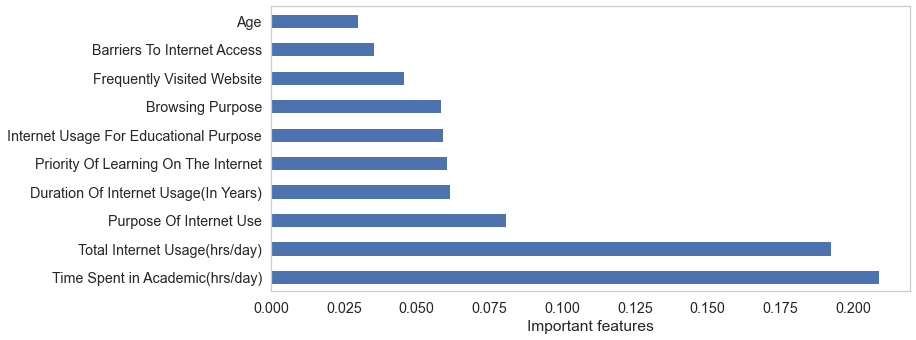

```python
plt.figure(figsize=(13, 5))
sns.set(font_scale=1.3)
sns.set_style("whitegrid", {'axes.grid' : False})

feat_importances.nlargest(10).plot(kind='barh')

plt.xlabel('Important features')

save_fig('top_ten_important_features')
plt.show()
```

**Correlation Matrix with Heatmap**

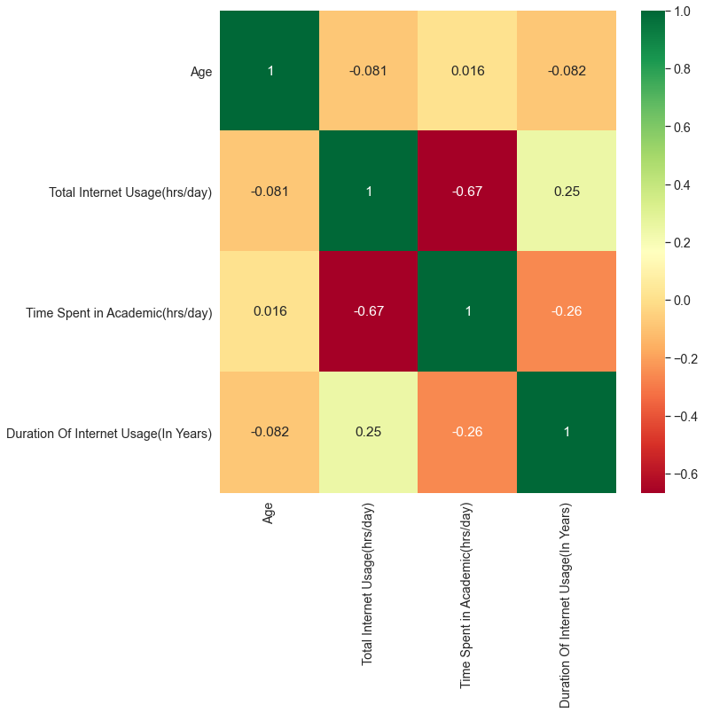

```python
import pandas as pd
import numpy as np
import seaborn as sns

#get correlations of each features in dataset
corrmat = school_df.corr()
top_corr_features = corrmat.index
plt.figure(figsize=(10,10))

#plot heat map
g=sns.heatmap(school_df[top_corr_features].corr(),annot=True,cmap="RdYlGn")
```

## Hyperparameter Optimization

hyperparameter optimization or tuning is the problem of choosing a set of optimal hyperparameters for a learning algorithm. A hyperparameter is a parameter whose value is used to control the learning process. By contrast, the values of other parameters (typically node weights) are learned.

We'll perform hyperparameter optimization using the following optimization techniques:

1. **`GridSearchCV`** - Exhaustive search over specified parameter values for an estimator.
1. **`RandomizedSearchCV`** - Randomized search on hyper parameters. The parameters of the estimator used to apply these methods are optimized by cross-validated search over parameter settings.
1. **`BayesSearchCV`** - Bayesian Optimization of model hyperparameters provided by the Scikit-Optimize library.
1. **Genetic Algorithm using the TPOT library** - TPOT is an open-source library for performing AutoML in Python. It makes use of the popular Scikit-Learn machine learning library for data transforms and machine learning algorithms and uses a Genetic Programming stochastic global search procedure to efficiently discover a top-performing model pipeline for a given dataset.

Let's start with `GridSearchCV`.

## Hyperparameter Optimization using `GridSearchCV`

As we saw, the algorithms that performs the best are `MultinomialNB`, `RandomForestClassifier`, `LogisticRegression` and `SGDClassifier`. Let's try and optimize the `LogisticRegression` algorithm more to get a better result. First let's see the parameters that we'll try and tune in the `LogisticRegression`.

```python
from sklearn.linear_model import LogisticRegression
from sklearn import metrics

log_reg = LogisticRegression()

log_reg.get_params().keys()
```

```
dict_keys(['C', 'class_weight', 'dual', 'fit_intercept', 'intercept_scaling', 'l1_ratio', 'max_iter', 'multi_class', 'n_jobs', 'penalty', 'random_state', 'solver', 'tol', 'verbose', 'warm_start'])
```

Let's create a dictionary that defines the parameters that we want to optimize.

```python
param_grid  = { 'penalty' : ['l2'],
                'C' : list(np.logspace(-4, 4, 6)),
                'max_iter': list(range(100, 2000, 100)),
                'solver': ['lbfgs', 'liblinear', 'newton-cg', 'sag', 'saga'],
                'warm_start' : [True, False]
            }

print(param_grid)
```

[output not shown]

Now, let's optimize the model using `GridSearchCV`. The method we'll use for cross validation is `RepeatedStratifiedKFold`.

```python
from sklearn.model_selection import GridSearchCV
from sklearn.model_selection import cross_val_score
from sklearn.model_selection import RepeatedStratifiedKFold

# define evaluation
cv = RepeatedStratifiedKFold(n_splits=5, n_repeats=3, random_state=1)

# define the search
gs_log_reg = GridSearchCV(log_reg, param_grid=param_grid, scoring='accuracy', n_jobs=-1, cv=cv)

gs_log_reg.fit(X_train, y_train)

gs_log_reg.best_params_
```

```
{'C': 0.15848931924611143,
 'max_iter': 100,
 'penalty': 'l2',
 'solver': 'newton-cg',
 'warm_start': True}
```

```python
gs_log_reg.score(X_train, y_train)
```

```
0.9136690647482014
```

Let's put the model to use and predict our test set.

```python
y_pred_gs_log = gs_log_reg.predict(X_test)

conf_mat = confusion_matrix(y_test, y_pred_gs_log)
class_report = classification_report(y_test, y_pred_gs_log)


print("Accuracy:", metrics.accuracy_score(y_test, y_pred_gs_log))

print(conf_mat)
print(class_report)
```

```
Accuracy: 0.7333333333333333
[[10  2  0  3]
 [ 0 32  0  0]
 [ 0  9  0  0]
 [ 2  0  0  2]]
                  precision    recall  f1-score   support

         Average       0.83      0.67      0.74        15
       Excellent       0.74      1.00      0.85        32
            Good       0.00      0.00      0.00         9
Not Satisfactory       0.40      0.50      0.44         4

        accuracy                           0.73        60
       macro avg       0.49      0.54      0.51        60
    weighted avg       0.63      0.73      0.67        60
```

## Hyperparameter Optimization using `RandomizedSearchCV`

As we saw, the algorithms that performs the best are `MultinomialNB`, `RandomForestClassifier`, `LogisticRegression` and `SGDClassifier`. Let's try and optimize the `LogisticRegression` algorithm more to get a better result. First let's see the parameters that we'll try and tune in the `LogisticRegression`.

We'll use the same dictionary that we created before as the parameters that we want to optimize. Now, let's optimize the model using `RandomizedSearchCV`. The method we'll use for cross validation is `RepeatedStratifiedKFold`.

```python
from sklearn.model_selection import RandomizedSearchCV
from sklearn.model_selection import cross_val_score
from sklearn.model_selection import RepeatedStratifiedKFold

# define evaluation
cv = RepeatedStratifiedKFold(n_splits=10, n_repeats=3, random_state=1)

rs_log_reg = RandomizedSearchCV(log_reg, param_grid, scoring='accuracy', cv=cv)

rs_log_reg.fit(X_train, y_train)

rs_log_reg.best_params_
```

[output not shown]

[output cut: 489 more lines]

[output not shown]

```
{'warm_start': False,
 'solver': 'saga',
 'penalty': 'l2',
 'max_iter': 500,
 'C': 6.309573444801943}
```

Let's check the training score. It should be performing much better now.

```python
rs_log_reg.score(X_train, y_train)
```

```
0.9496402877697842
```

Let's put the model to use and predict our test set.

```python
y_pred_rs_log = rs_log_reg.predict(X_test)

conf_mat = confusion_matrix(y_test, y_pred_rs_log)
class_report = classification_report(y_test, y_pred_rs_log)


print("Accuracy:", metrics.accuracy_score(y_test, y_pred_rs_log))

print(conf_mat)
print(class_report)
```

```
Accuracy: 0.7333333333333333
[[10  2  0  3]
 [ 1 31  0  0]
 [ 0  8  1  0]
 [ 2  0  0  2]]
                  precision    recall  f1-score   support

         Average       0.77      0.67      0.71        15
       Excellent       0.76      0.97      0.85        32
            Good       1.00      0.11      0.20         9
Not Satisfactory       0.40      0.50      0.44         4

        accuracy                           0.73        60
       macro avg       0.73      0.56      0.55        60
    weighted avg       0.77      0.73      0.69        60
```

## Hyperparameter Optimization using `BayesSearchCV`

As we saw, the algorithms that performs the best are `MultinomialNB`, `RandomForestClassifier`, `LogisticRegression` and `SGDClassifier`. Let's try and optimize the `LogisticRegression` algorithm more to get a better result. First let's see the parameters that we'll try and tune in the `LogisticRegression`.

We'll use the same dictionary that we created before as the parameters that we want to optimize. Now, let's optimize the model using **Bayesian Optimization** implemented in `BayesSearchCV`. `skopt` library contains this class. The method we'll use for cross validation is `RepeatedStratifiedKFold`.

```python
from sklearn.model_selection import cross_val_score
from sklearn.model_selection import RepeatedStratifiedKFold
from skopt import BayesSearchCV


# define evaluation
cv = RepeatedStratifiedKFold(n_splits=10, n_repeats=3, random_state=1)

# define the search
bs_log_reg = BayesSearchCV(estimator=log_reg, search_spaces=param_grid, n_jobs=-1, cv=cv)

# perform the search
bs_log_reg.fit(X, y)

# report the best result
print(bs_log_reg.best_score_)
print(bs_log_reg.best_params_)
```

```
0.8157894736842105
OrderedDict([('C', 0.15848931924611143), ('max_iter', 1000), ('penalty', 'l2'), ('solver', 'liblinear'), ('warm_start', True)])
```

```python
bs_log_reg.score(X_train, y_train)
```

```
0.8848920863309353
```

Let's put the model to use and predict our test set.

```python
y_pred_bs_log = bs_log_reg.predict(X_test)

conf_mat = confusion_matrix(y_test, y_pred_bs_log)
class_report = classification_report(y_test, y_pred_bs_log)


print("Accuracy:", metrics.accuracy_score(y_test, y_pred_bs_log))

print(conf_mat)
print(class_report)
```

```
Accuracy: 0.7833333333333333
[[12  2  0  1]
 [ 0 32  0  0]
 [ 0  8  1  0]
 [ 2  0  0  2]]
                  precision    recall  f1-score   support

         Average       0.86      0.80      0.83        15
       Excellent       0.76      1.00      0.86        32
            Good       1.00      0.11      0.20         9
Not Satisfactory       0.67      0.50      0.57         4

        accuracy                           0.78        60
       macro avg       0.82      0.60      0.62        60
    weighted avg       0.82      0.78      0.74        60
```

## Hyperparameter Optimization using `Genetic Algorithm`

Genetic Algorithms(GAs) are adaptive heuristic search algorithms that belong to the larger part of evolutionary algorithms. Genetic algorithms are based on the ideas of natural selection and genetics. These are intelligent exploitation of random search provided with historical data to direct the search into the region of better performance in solution space. They are commonly used to generate high-quality solutions for optimization problems and search problems.

Genetic algorithms simulate the process of natural selection which means those species who can adapt to changes in their environment are able to survive and reproduce and go to next generation. In simple words, they simulate “survival of the fittest” among individual of consecutive generation for solving a problem. Each generation consist of a population of individuals and each individual represents a point in search space and possible solution. Each individual is represented as a string of character/integer/float/bits. This string is analogous to the Chromosome.

To implement genetic algorithm we'll use **TPOT** which is an open-source library for performing AutoML in Python. It makes use of the popular Scikit-Learn machine learning library for data transforms and machine learning algorithms and uses a Genetic Programming stochastic global search procedure to efficiently discover a top-performing model pipeline for a given dataset.

We'll first have to numberize the training and test label set. Here we use `sklearn`'s `LabelEncoder` class to implement this.

```python
# label_encoder object knows how to understand word labels.
label_encoder = preprocessing.LabelEncoder()

y_train_n = label_encoder.fit_transform(y_train)
y_test_n = label_encoder.fit_transform(y_test)

y_train_n
```

```
array([1, 1, 1, 1, 0, 1, 1, 1, 1, 0, 1, 1, 1, 1, 1, 1, 1, 3, 0, 0, 0, 0,
       1, 1, 1, 1, 1, 1, 0, 1, 1, 1, 1, 1, 1, 2, 3, 1, 1, 1, 1, 1, 1, 0,
       1, 1, 2, 1, 0, 0, 1, 1, 3, 1, 1, 1, 1, 1, 1, 0, 1, 1, 0, 1, 3, 1,
       0, 1, 0, 1, 1, 1, 2, 1, 1, 1, 1, 0, 1, 1, 1, 2, 1, 1, 1, 1, 3, 0,
       1, 2, 1, 1, 1, 1, 2, 1, 3, 0, 1, 3, 1, 1, 1, 1, 0, 0, 1, 1, 1, 0,
       1, 0, 1, 1, 0, 1, 1, 1, 3, 0, 1, 1, 0, 2, 1, 1, 3, 1, 1, 1, 1, 1,
       3, 0, 0, 1, 1, 0, 2])
```

```python
y_train.head(30)
```

```
112           Excellent
156           Excellent
26            Excellent
0             Excellent
123             Average
148           Excellent
137           Excellent
116           Excellent
158           Excellent
76              Average
166           Excellent
48            Excellent
40            Excellent
16            Excellent
13            Excellent
```

[output cut: 16 more lines]

Here we see our labels are encoded according to the following:

1. **Excellent - 1**
1. **Good - 2**
1. **Average - 0**
1. **Not Satisfactory - 3**

**Let's finally train the Genetic Algorithm using `TPOTClassifier`. We are currently using 15 `generations`, 100 `population_size` and 150 `offspring_size`.**

```python
from tpot import TPOTClassifier


tpot = TPOTClassifier(generations=15, population_size=100, offspring_size=150,
                      verbosity=2, early_stop=8, cv = 10, scoring = 'accuracy',
                      random_state=42)

tpot.fit(X_train, y_train_n)
print(tpot.score(X_test, y_test_n))
tpot.export('tpot_digits_pipeline_school.py')
```

```
Generation 1 - Current best internal CV score: 0.8774725274725276

Generation 2 - Current best internal CV score: 0.8846153846153847

Generation 3 - Current best internal CV score: 0.8846153846153847

Generation 4 - Current best internal CV score: 0.8846153846153847

Generation 5 - Current best internal CV score: 0.9065934065934066

Generation 6 - Current best internal CV score: 0.9065934065934066

Generation 7 - Current best internal CV score: 0.9065934065934066

Generation 8 - Current best internal CV score: 0.9065934065934066

Generation 9 - Current best internal CV score: 0.9065934065934066

Generation 10 - Current best internal CV score: 0.9065934065934066

Generation 11 - Current best internal CV score: 0.9065934065934066

Generation 12 - Current best internal CV score: 0.9142857142857143

Generation 13 - Current best internal CV score: 0.9142857142857143

Generation 14 - Current best internal CV score: 0.9142857142857143

Generation 15 - Current best internal CV score: 0.9142857142857143

Best pipeline: RandomForestClassifier(Normalizer(MultinomialNB(GaussianNB(input_matrix), alpha=0.01, fit_prior=True), norm=l2), bootstrap=True, criterion=entropy, max_features=0.4, min_samples_leaf=1, min_samples_split=16, n_estimators=100)
0.7166666666666667
```

**Genetic algorithm showed us that the most optimized algorithm is the `RandomForestClassifier` with the following parameter :**

**`RandomForestClassifier(Normalizer(MultinomialNB(GaussianNB(input_matrix), alpha=0.01, fit_prior=True), norm=l2), bootstrap=True, criterion=entropy, max_features=0.4, min_samples_leaf=1, min_samples_split=16, n_estimators=100)`**

**Let's fit this algorithm to our dataset and check the training score.**

```python
import numpy as np
import pandas as pd
from sklearn.ensemble import RandomForestClassifier
from sklearn.model_selection import train_test_split
from sklearn.naive_bayes import GaussianNB, MultinomialNB
from sklearn.pipeline import make_pipeline, make_union
from sklearn.preprocessing import Normalizer
from tpot.builtins import StackingEstimator
from tpot.export_utils import set_param_recursive


# Average CV score on the training set was: 0.9142857142857143
exported_pipeline = make_pipeline(
    StackingEstimator(estimator=GaussianNB()),
    StackingEstimator(estimator=MultinomialNB(alpha=0.01, fit_prior=True)),
    Normalizer(norm="l2"),
    RandomForestClassifier(bootstrap=True, criterion="entropy", max_features=0.4, min_samples_leaf=1,
                           min_samples_split=16, n_estimators=100)
)
# Fix random state for all the steps in exported pipeline
set_param_recursive(exported_pipeline.steps, 'random_state', 42)

exported_pipeline.fit(X_train, y_train_n)
results = exported_pipeline.predict(X_test)

score = exported_pipeline.score(X_train, y_train_n)
print("Training score: ", score)
```

```
Training score:  0.9496402877697842
```

**Let's check the accuracy on the test set and check the confusion matrix, precision, recall and f1 scores.**

```python
from sklearn.metrics import confusion_matrix
from sklearn.metrics import classification_report


conf_mat = confusion_matrix(y_test_n, results)
class_report = classification_report(y_test_n, results)


print("Accuracy:", metrics.accuracy_score(y_test_n, results))

print(conf_mat)
print(class_report)
```

```
Accuracy: 0.7166666666666667
[[10  2  0  3]
 [ 1 31  0  0]
 [ 0  9  0  0]
 [ 2  0  0  2]]
              precision    recall  f1-score   support

           0       0.77      0.67      0.71        15
           1       0.74      0.97      0.84        32
           2       0.00      0.00      0.00         9
           3       0.40      0.50      0.44         4

    accuracy                           0.72        60
   macro avg       0.48      0.53      0.50        60
weighted avg       0.61      0.72      0.66        60
```

**Finally, let's perform `KFold` cross validation.**

```python
from sklearn.model_selection import cross_val_score
from sklearn.model_selection import KFold


cv_ga = KFold(n_splits=10, shuffle=True, random_state=42)

scores = cross_val_score(exported_pipeline, X_train, y_train_n, cv=cv_ga, scoring="accuracy", n_jobs=-1)
print('Training Accuracy On KFold Cross Validation: %.3f (%.3f)' % (np.mean(scores), np.std(scores)))

scores = cross_val_score(exported_pipeline, X_test, y_test_n, cv=cv_ga, scoring="accuracy", n_jobs=-1)
print('Testing Accuracy On KFold Cross Validation: %.3f (%.3f)' % (np.mean(scores), np.std(scores)))
```

```
Training Accuracy On KFold Cross Validation: 0.870 (0.089)
Testing Accuracy On KFold Cross Validation: 0.683 (0.117)
```

**This model givess us a 68.3% accuracy on `KFold` cross validation.**